# Part I - an_analysis_of_features_which_have_the_most_influence_of_loan_outcomes

## Introduction

> This dataset is data on loans from prosper. This data set contains 113,937 loans with 81 variables on each loan, including loan amount, borrower rate (or interest rate), current loan status, borrower income, and many others. Of these I selected a subset of 23 features and Loan status column. Of the subset a smaller subset of loan status, employment status, listing category, borrower rates and howeowners are used as they show lage variations across the factors being observed, Loan status.

## Preliminary Wrangling

```python
# import all packages and set plots to be embedded inline
import numpy as np
import pandas as pd
import matplotlib.pyplot as plt
import seaborn as sb

%matplotlib inline
```

```python
df= pd.read_csv('prosperLoanData.csv')

df.info()
```

```
<class 'pandas.core.frame.DataFrame'>
RangeIndex: 113937 entries, 0 to 113936
Data columns (total 81 columns):
 #   Column                               Non-Null Count   Dtype
---  ------                               --------------   -----
 0   ListingKey                           113937 non-null  object
 1   ListingNumber                        113937 non-null  int64
 2   ListingCreationDate                  113937 non-null  object
 3   CreditGrade                          28953 non-null   object
 4   Term                                 113937 non-null  int64
 5   LoanStatus                           113937 non-null  object
 6   ClosedDate                           55089 non-null   object
 7   BorrowerAPR                          113912 non-null  float64
 8   BorrowerRate                         113937 non-null  float64
 9   LenderYield                          113937 non-null  float64
```

[output cut: 73 more lines]

```python
df[df.duplicated()]
```

|  | ListingKey | ListingNumber | ListingCreationDate | CreditGrade | Term | LoanStatus | ClosedDate | BorrowerAPR | BorrowerRate | LenderYield | ... | LP_ServiceFees | LP_CollectionFees | LP_GrossPrincipalLoss | LP_NetPrincipalLoss | LP_NonPrincipalRecoverypayments | PercentFunded | Recommendations | InvestmentFromFriendsCount | InvestmentFromFriendsAmount | Investors |
| --- | --- | --- | --- | --- | --- | --- | --- | --- | --- | --- | --- | --- | --- | --- | --- | --- | --- | --- | --- | --- | --- |

0 rows × 81 columns

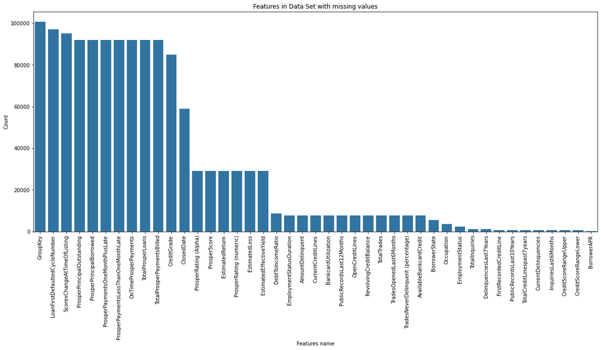

```python
isnull_df= df.isna().sum().reset_index().sort_values(0, ascending= False)
# plotting a horizontal barchart of null values in the dataset
plt.figure(figsize=[20,8])

sb.barplot(data=isnull_df[isnull_df[0]>0], y=0, x='index', color=sb.color_palette()[0])
plt.xlabel('Features name')
plt.ylabel('Count')
plt.title('Features in Data Set with missing values')
plt.xticks(rotation=90);
```

### Main feature(s) of interest in your dataset?

> I am most interested in the what determines a loan outcome and what determines borrower rate.

### Features in the dataset which could help support my investigation into Loan Status outcomes?

```python
# creating a sub_dataframe of in features i will be exploring

loan_df= df[['ListingCreationDate', 'Term', 'LoanStatus', 'BorrowerAPR',
          'BorrowerRate', 'ListingCategory (numeric)', 'BorrowerState',
          'Occupation', 'EmploymentStatus', 'EmploymentStatusDuration',
          'IsBorrowerHomeowner', 'CreditScoreRangeLower', 'CreditScoreRangeUpper',
          'RevolvingCreditBalance', 'BankcardUtilization', 'AvailableBankcardCredit',
          'DebtToIncomeRatio', 'IncomeRange', 'IncomeVerifiable', 'StatedMonthlyIncome',
          'MonthlyLoanPayment', 'Recommendations', 'Investors', 'LoanOriginalAmount']]
len(loan_df)
```

```
113937
```

## Univariate Exploration

> In this section, I will be looking at individual variables and their distribution.

```python
loan_df.head()
```

|  | ListingCreationDate | Term | LoanStatus | BorrowerAPR | BorrowerRate | ListingCategory (numeric) | BorrowerState | Occupation | EmploymentStatus | EmploymentStatusDuration | ... | BankcardUtilization | AvailableBankcardCredit | DebtToIncomeRatio | IncomeRange | IncomeVerifiable | StatedMonthlyIncome | MonthlyLoanPayment | Recommendations | Investors | LoanOriginalAmount |
| --- | --- | --- | --- | --- | --- | --- | --- | --- | --- | --- | --- | --- | --- | --- | --- | --- | --- | --- | --- | --- | --- |
| 0 | 2007-08-26 19:09:29.263000000 | 36 | Completed | 0.16516 | 0.1580 | 0 | CO | Other | Self-employed | 2.0 | ... | 0.00 | 1500.0 | 0.17 | $25,000-49,999 | True | 3083.333333 | 330.43 | 0 | 258 | 9425 |
| 1 | 2014-02-27 08:28:07.900000000 | 36 | Current | 0.12016 | 0.0920 | 2 | CO | Professional | Employed | 44.0 | ... | 0.21 | 10266.0 | 0.18 | $50,000-74,999 | True | 6125.000000 | 318.93 | 0 | 1 | 10000 |
| 2 | 2007-01-05 15:00:47.090000000 | 36 | Completed | 0.28269 | 0.2750 | 0 | GA | Other | Not available | NaN | ... | NaN | NaN | 0.06 | Not displayed | True | 2083.333333 | 123.32 | 0 | 41 | 3001 |
| 3 | 2012-10-22 11:02:35.010000000 | 36 | Current | 0.12528 | 0.0974 | 16 | GA | Skilled Labor | Employed | 113.0 | ... | 0.04 | 30754.0 | 0.15 | $25,000-49,999 | True | 2875.000000 | 321.45 | 0 | 158 | 10000 |
| 4 | 2013-09-14 18:38:39.097000000 | 36 | Current | 0.24614 | 0.2085 | 2 | MN | Executive | Employed | 44.0 | ... | 0.81 | 695.0 | 0.26 | $100,000+ | True | 9583.333333 | 563.97 | 0 | 20 | 15000 |

5 rows × 24 columns

```python
# renaming the columns
a= ['Listing_Creation_Date', 'Term', 'Loan_Status', 'Borrower_APR',
       'Borrower_Rate', 'Listing_Category', 'Borrower_State',
       'Occupation', 'Employment_Status', 'Employment_Status_Duration',
       'Is_Borrower_Home_owner', 'Credit_Score_Range_Lower', 'Credit_Score_Range_Upper',
       'Revolving_Credit_Balance', 'Bank_card_Utilization',
       'Available_Bank_card_Credit', 'Debt_To_Income_Ratio', 'Income_Range',
       'Income_Verifiable', 'Stated_Monthly_Income', 'Monthly_Loan_Payment',
    'Recommendations', 'Investors', 'Loan_Original_Amount']

b= [x.lower() for x in a]

loan_df.columns= b
```

```python
loan_df.head()
```

|  | listing_creation_date | term | loan_status | borrower_apr | borrower_rate | listing_category | borrower_state | occupation | employment_status | employment_status_duration | ... | bank_card_utilization | available_bank_card_credit | debt_to_income_ratio | income_range | income_verifiable | stated_monthly_income | monthly_loan_payment | recommendations | investors | loan_original_amount |
| --- | --- | --- | --- | --- | --- | --- | --- | --- | --- | --- | --- | --- | --- | --- | --- | --- | --- | --- | --- | --- | --- |
| 0 | 2007-08-26 19:09:29.263000000 | 36 | Completed | 0.16516 | 0.1580 | 0 | CO | Other | Self-employed | 2.0 | ... | 0.00 | 1500.0 | 0.17 | $25,000-49,999 | True | 3083.333333 | 330.43 | 0 | 258 | 9425 |
| 1 | 2014-02-27 08:28:07.900000000 | 36 | Current | 0.12016 | 0.0920 | 2 | CO | Professional | Employed | 44.0 | ... | 0.21 | 10266.0 | 0.18 | $50,000-74,999 | True | 6125.000000 | 318.93 | 0 | 1 | 10000 |
| 2 | 2007-01-05 15:00:47.090000000 | 36 | Completed | 0.28269 | 0.2750 | 0 | GA | Other | Not available | NaN | ... | NaN | NaN | 0.06 | Not displayed | True | 2083.333333 | 123.32 | 0 | 41 | 3001 |
| 3 | 2012-10-22 11:02:35.010000000 | 36 | Current | 0.12528 | 0.0974 | 16 | GA | Skilled Labor | Employed | 113.0 | ... | 0.04 | 30754.0 | 0.15 | $25,000-49,999 | True | 2875.000000 | 321.45 | 0 | 158 | 10000 |
| 4 | 2013-09-14 18:38:39.097000000 | 36 | Current | 0.24614 | 0.2085 | 2 | MN | Executive | Employed | 44.0 | ... | 0.81 | 695.0 | 0.26 | $100,000+ | True | 9583.333333 | 563.97 | 0 | 20 | 15000 |

5 rows × 24 columns

### 1. Investigating the loan status column

```python
# What is the data type?
loan_df[['loan_status']].info()
```

```
<class 'pandas.core.frame.DataFrame'>
RangeIndex: 113937 entries, 0 to 113936
Data columns (total 1 columns):
 #   Column       Non-Null Count   Dtype
---  ------       --------------   -----
 0   loan_status  113937 non-null  object
dtypes: object(1)
memory usage: 890.3+ KB
```

```python
# what are the unique values in the loan status column
loan_df['loan_status'].unique()
```

```
array(['Completed', 'Current', 'Past Due (1-15 days)', 'Defaulted',
       'Chargedoff', 'Past Due (16-30 days)', 'Cancelled',
       'Past Due (61-90 days)', 'Past Due (31-60 days)',
       'Past Due (91-120 days)', 'FinalPaymentInProgress',
       'Past Due (>120 days)'], dtype=object)
```

```python
# Does the column contain missing values?
loan_df['loan_status'].isna().sum()
```

```
0
```

```python
def redefine_past(x):
    """
    This function checks if the first four letters in a string are 'Past' and replaces that with 'Past due'
    """
    if x.startswith('Past'):
        return 'Past Due'
    else:
        return x
```

```python
# grouping all the past due columns into one
loan_df_ol= loan_df.copy()
loan_df_ol['loan_status']= loan_df_ol['loan_status'].apply(redefine_past)

# creating a categorical data of the loan status column
loan_status_classes= ['Completed', 'FinalPaymentInProgress', 'Current', 'Past Due', 'Defaulted', 'Chargedoff', 'Cancelled']
l_classes= pd.api.types.CategoricalDtype(ordered=True, categories=loan_status_classes)
```

```python
# checking if the changes applied worked
loan_df_ol['loan_status'].unique()
```

```
array(['Completed', 'Current', 'Past Due', 'Defaulted', 'Chargedoff',
       'Cancelled', 'FinalPaymentInProgress'], dtype=object)
```

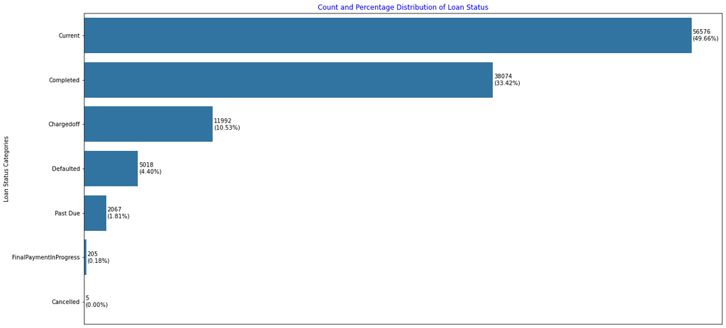

```python
# univariate data exploration

def plot_univa(df, col, col_title, x, y):
    """
    This function creates a count plot with the count and percentage of each bar shown infront of the plot
    """
    type_count= df[col].value_counts()
    type_order= type_count.index
    type_sum= sum(type_count.values)

    plt.figure(figsize=[x, y])
    sb.countplot(data=df, y=col, color=sb.color_palette()[0], order=df[col].value_counts().index)
    plt.title(f'Count and Percentage Distribution of {col_title}', color='b')
    plt.ylabel(f'{col_title} Categories')
    plt.xlabel(None)
    plt.tick_params(axis='x', which='both', bottom=False, top=False, labelbottom=False)

    for i in range(type_count.shape[0]):
        count= type_count[i]
        pct_string= '{}\n({:0.2f}%)'.format(count, count/type_sum*100)
        plt.text(count+100, i, pct_string, va= 'center')

plot_univa(loan_df_ol, 'loan_status', 'Loan Status', 20, 10)
```

#### Observations from the Loan staus column:

1. From the plot chart above we can see that the out if the current observations in the data, 50% are currently under a type of loan, 33% completed the loan, while 17% belond to some state of defaulted, charged off or past due.

### 2. Investigating the Listing Category Column

```python
# Checking the datatype
loan_df[['listing_category']].info()
```

```
<class 'pandas.core.frame.DataFrame'>
RangeIndex: 113937 entries, 0 to 113936
Data columns (total 1 columns):
 #   Column            Non-Null Count   Dtype
---  ------            --------------   -----
 0   listing_category  113937 non-null  int64
dtypes: int64(1)
memory usage: 890.3 KB
```

```python
# what are the unique values in the loan status column
loan_df['listing_category'].unique()
```

```
array([ 0,  2, 16,  1,  7, 13,  6, 15, 20, 19,  3, 18,  8,  4, 11, 14,  5,
        9, 17, 10, 12], dtype=int64)
```

```python
listing_dict= {0:'Not Available', 1:'Debt Consolidation', 2:'Home Improvement', 3:'Business',
                4:'Personal Loan', 5:'Student Use', 6:'Auto', 7:'Other', 8:'Baby&Adoption',
                9:'Boat', 10:'Cosmetic Procedure', 11:'Engagement Ring', 12:'Green Loans',
                13:'Household Expenses', 14:'Large Purchases', 15:'Medical/Dental',
                16:'Motorcycle', 17:'RV', 18:'Taxes', 19:'Vacation', 20:'Wedding Loans'}

def rep_listings(x):
    return listing_dict[x]

loan_df_ol['listing_category']= loan_df_ol['listing_category'].apply(rep_listings)
```

```python
# what are the unique values in the loan status column
loan_df_ol['listing_category'].unique()
```

```
array(['Not Available', 'Home Improvement', 'Motorcycle',
       'Debt Consolidation', 'Other', 'Household Expenses', 'Auto',
       'Medical/Dental', 'Wedding Loans', 'Vacation', 'Business', 'Taxes',
       'Baby&Adoption', 'Personal Loan', 'Engagement Ring',
       'Large Purchases', 'Student Use', 'Boat', 'RV',
       'Cosmetic Procedure', 'Green Loans'], dtype=object)
```

```python
# Does the column contain missing values?
loan_df_ol['loan_status'].isna().sum()
```

```
0
```

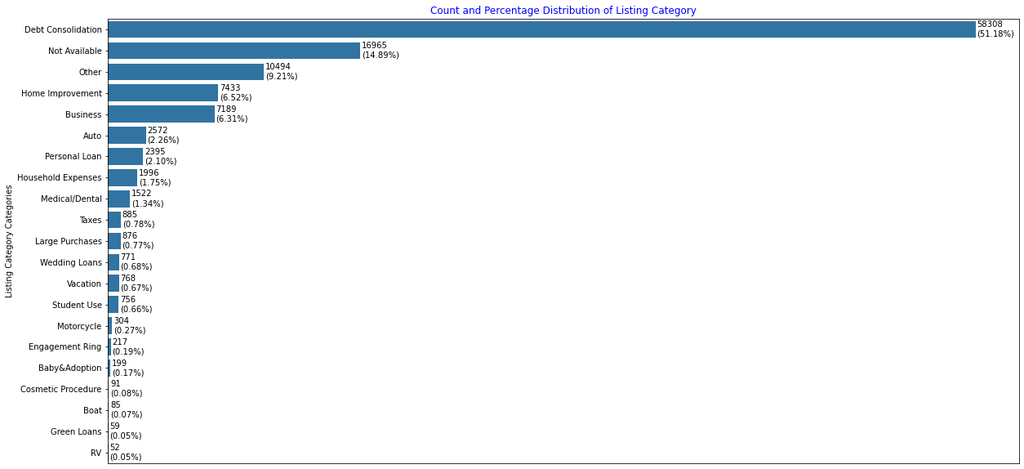

```python
# univariate data exploration
plot_univa(loan_df_ol, 'listing_category', 'Listing Category', 20, 10)
```

#### Observations:

1. Most of the population access loans Debt Consolidation.

#### 3. Investigating the occupation column

```python
#checking the data type
loan_df_ol[['occupation']].info()
```

```
<class 'pandas.core.frame.DataFrame'>
RangeIndex: 113937 entries, 0 to 113936
Data columns (total 1 columns):
 #   Column      Non-Null Count   Dtype
---  ------      --------------   -----
 0   occupation  110349 non-null  object
dtypes: object(1)
memory usage: 890.3+ KB
```

```python
# What are the unique values in the occupations feature
loan_df_ol['occupation'].unique()
```

```
array(['Other', 'Professional', 'Skilled Labor', 'Executive',
       'Sales - Retail', 'Laborer', 'Food Service', 'Fireman',
       'Waiter/Waitress', 'Construction', 'Computer Programmer',
       'Sales - Commission', 'Retail Management', 'Engineer - Mechanical',
       'Military Enlisted', 'Clerical', nan, 'Teacher', 'Clergy',
       'Accountant/CPA', 'Attorney', 'Nurse (RN)', 'Analyst',
       "Nurse's Aide", 'Investor', 'Realtor', 'Flight Attendant',
       'Nurse (LPN)', 'Military Officer', 'Food Service Management',
       'Truck Driver', 'Administrative Assistant',
       'Police Officer/Correction Officer', 'Social Worker',
       'Tradesman - Mechanic', 'Medical Technician', 'Professor',
       'Postal Service', 'Civil Service', 'Pharmacist',
       'Tradesman - Electrician', 'Scientist', 'Dentist',
       'Engineer - Electrical', 'Architect', 'Landscaping',
       'Tradesman - Carpenter', 'Bus Driver', 'Tradesman - Plumber',
       'Engineer - Chemical', 'Doctor', 'Chemist',
       'Student - College Senior', 'Principal', "Teacher's Aide",
       'Pilot - Private/Commercial', 'Religious', 'Homemaker',
       'Student - College Graduate Student', 'Student - Technical School',
       'Psychologist', 'Biologist', 'Student - College Sophomore',
       'Judge', 'Student - College Junior', 'Car Dealer',
       'Student - Community College', 'Student - College Freshman'],
      dtype=object)
```

```python
# Does the column contain missing values?
loan_df_ol['occupation'].isna().sum()
```

```
3588
```

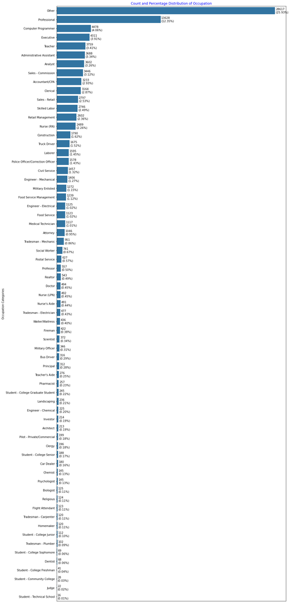

```python
# univariate data exploration
plot_univa(loan_df_ol, 'occupation', 'Occupation', 15, 40)
```

#### Observations from investigating the occupations column

1. 3588 (3.15%) of the data was missing
2. Non specific occupation types (other and professional) represents the most occupation type to access loans.

#### 4. Investigating the borrower apr and borrower rate

```python
# checking the data type
loan_df_ol[['borrower_apr', 'borrower_rate']].info()
```

```
<class 'pandas.core.frame.DataFrame'>
RangeIndex: 113937 entries, 0 to 113936
Data columns (total 2 columns):
 #   Column         Non-Null Count   Dtype
---  ------         --------------   -----
 0   borrower_apr   113912 non-null  float64
 1   borrower_rate  113937 non-null  float64
dtypes: float64(2)
memory usage: 1.7 MB
```

```python
# checking the summary statistics for the borrower apr and borrower rate
loan_df_ol[['borrower_apr', 'borrower_rate']].describe()
```

|  | borrower_apr | borrower_rate |
| --- | --- | --- |
| count | 113912.000000 | 113937.000000 |
| mean | 0.218828 | 0.192764 |
| std | 0.080364 | 0.074818 |
| min | 0.006530 | 0.000000 |
| 25% | 0.156290 | 0.134000 |
| 50% | 0.209760 | 0.184000 |
| 75% | 0.283810 | 0.250000 |
| max | 0.512290 | 0.497500 |

```python
# What are the unique values in the occupations feature
print('the borrower apr contains:', loan_df_ol['borrower_apr'].nunique(), 'unique values')
print('the borrower rate contains:', loan_df_ol['borrower_rate'].nunique(), 'unique values')
```

```
the borrower apr contains: 6677 unique values
the borrower rate contains: 2294 unique values
```

```python
# check for missing values in observations
print('the borrower apr contains:', loan_df_ol['borrower_apr'].isna().sum(), 'missing values')
print('the borrower rate contains:', loan_df_ol['borrower_rate'].isna().sum(), 'missin values')
```

```
the borrower apr contains: 25 missing values
the borrower rate contains: 0 missin values
```

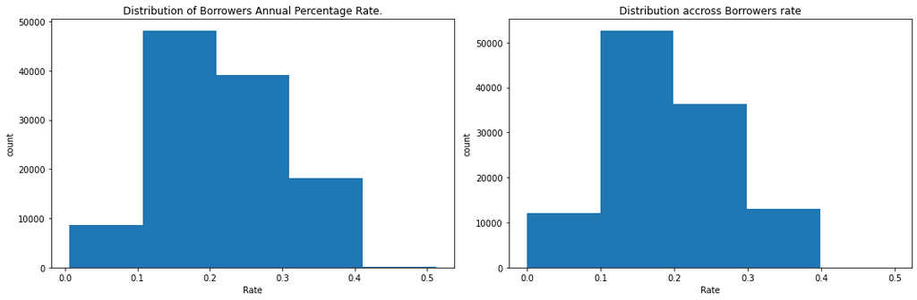

```python
# plotting the borrower apr and borrower rate on subplots

plt.figure(figsize=[15, 5])
plt.subplot(1,2,1)
bins=np.arange(0, loan_df_ol.borrower_apr.max(), 0.025)
plt.hist(data= loan_df, x='borrower_apr', bins=5)
plt.title('Distribution of Borrowers Annual Percentage Rate.')
plt.xlabel('Rate')
plt.ylabel('count')

plt.subplot(1,2,2)
bins=np.arange(0, loan_df.borrower_rate.max(), 0.025)
plt.hist(data= loan_df_ol, x='borrower_rate', bins=5)
plt.title('Distribution accross Borrowers rate')
plt.xlabel('Rate')
plt.ylabel('count')

plt.tight_layout()
```

##### Observations:

1. As expexcted the borrowers annual exchange rate has more unique values than borrowers rate as it shows an all year round moving average.
2. Both borrowers annual percentage rate and borrowers rate appear to have a normal distribution

#### 4. Investigating the credit score and credit score range upper- and lower

```python
# checking the data type
loan_df_ol[['credit_score_range_lower', 'credit_score_range_upper']].info()
```

```
<class 'pandas.core.frame.DataFrame'>
RangeIndex: 113937 entries, 0 to 113936
Data columns (total 2 columns):
 #   Column                    Non-Null Count   Dtype
---  ------                    --------------   -----
 0   credit_score_range_lower  113346 non-null  float64
 1   credit_score_range_upper  113346 non-null  float64
dtypes: float64(2)
memory usage: 1.7 MB
```

```python
loan_df_ol[['credit_score_range_lower', 'credit_score_range_upper']].describe()
```

|  | credit_score_range_lower | credit_score_range_upper |
| --- | --- | --- |
| count | 113346.000000 | 113346.000000 |
| mean | 685.567731 | 704.567731 |
| std | 66.458275 | 66.458275 |
| min | 0.000000 | 19.000000 |
| 25% | 660.000000 | 679.000000 |
| 50% | 680.000000 | 699.000000 |
| 75% | 720.000000 | 739.000000 |
| max | 880.000000 | 899.000000 |

```python
# What are the unique values in the occupations feature
print('the Credit score range lower contains:', loan_df_ol['credit_score_range_lower'].nunique(), 'unique values')
print('the Credit score range upper contains:', loan_df_ol['credit_score_range_upper'].nunique(), 'unique values')
```

```
the Credit score range lower contains: 26 unique values
the Credit score range upper contains: 26 unique values
```

```python
# checcking for missing values
loan_df_ol[['credit_score_range_lower', 'credit_score_range_upper']].isna().sum()
```

```
credit_score_range_lower    591
credit_score_range_upper    591
dtype: int64
```

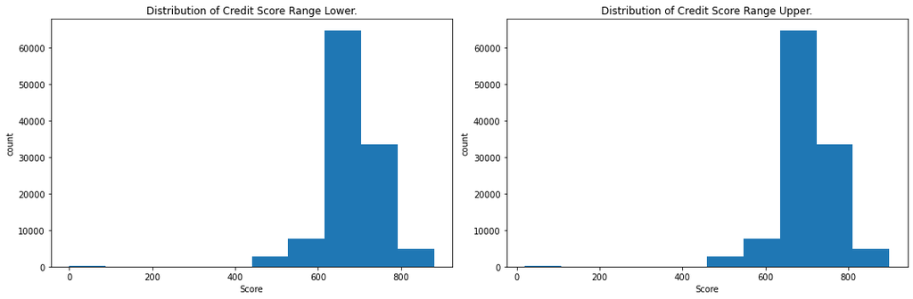

```python
# plotting the credit score range - lower and upper; on subplots

plt.figure(figsize=[15, 5])
plt.subplot(1,2,1)
bins=np.arange(0, loan_df_ol.borrower_apr.max(), 0.025)
plt.hist(data= loan_df, x='credit_score_range_lower', bins=10)
plt.title('Distribution of Credit Score Range Lower.')
plt.xlabel('Score')
plt.ylabel('count')

plt.subplot(1,2,2)
bins=np.arange(0, loan_df_ol.borrower_rate.max(), 0.025)
plt.hist(data= loan_df, x='credit_score_range_upper', bins=10)
plt.title('Distribution of Credit Score Range Upper.')
plt.xlabel('Score')
plt.ylabel('count')

plt.tight_layout()
```

##### Observation:

1. The difference between thecredit score range - upper and lower, is the start values and end values, of which the upper range offsets the lower range by 19
2. there are outliers in the data credit score range set

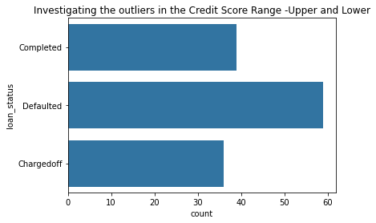

```python
# Masking the dataset by all values less than 400
sb.countplot(data= loan_df_ol[(loan_df_ol['credit_score_range_lower']< 400) & (loan_df_ol['credit_score_range_upper']< 419)][['loan_status', 'credit_score_range_lower', 'credit_score_range_upper']],
              y='loan_status',
              color= sb.color_palette()[0])
plt.title('Investigating the outliers in the Credit Score Range -Upper and Lower')
```

##### Observations:

1. observations with a lower credit score greater than 600 and an upper credit score less than 820, represent the bulk of our observations.
2. There are 133 outliers. There are observations abnormally low credit scores who were offered loans.  
   Of these lots, approximately 60 have defaulted,

#### 5. investigating revolving credit balance, bank card utilization, and available bank card credit

```python
# checking the data type
loan_df_ol[['revolving_credit_balance', 'bank_card_utilization', 'available_bank_card_credit']].info()
```

```
<class 'pandas.core.frame.DataFrame'>
RangeIndex: 113937 entries, 0 to 113936
Data columns (total 3 columns):
 #   Column                      Non-Null Count   Dtype
---  ------                      --------------   -----
 0   revolving_credit_balance    106333 non-null  float64
 1   bank_card_utilization       106333 non-null  float64
 2   available_bank_card_credit  106393 non-null  float64
dtypes: float64(3)
memory usage: 2.6 MB
```

```python
loan_df_ol[['revolving_credit_balance', 'bank_card_utilization', 'available_bank_card_credit']].describe()
```

|  | revolving_credit_balance | bank_card_utilization | available_bank_card_credit |
| --- | --- | --- | --- |
| count | 1.063330e+05 | 106333.000000 | 106393.000000 |
| mean | 1.759871e+04 | 0.561309 | 11210.225447 |
| std | 3.293640e+04 | 0.317918 | 19818.361309 |
| min | 0.000000e+00 | 0.000000 | 0.000000 |
| 25% | 3.121000e+03 | 0.310000 | 880.000000 |
| 50% | 8.549000e+03 | 0.600000 | 4100.000000 |
| 75% | 1.952100e+04 | 0.840000 | 13180.000000 |
| max | 1.435667e+06 | 5.950000 | 646285.000000 |

```python
# What are the unique values in the occupations feature
print('the Revolving credit balance contains:', loan_df_ol['revolving_credit_balance'].nunique(), 'unique values')
print('the Bank card utilization contains:', loan_df_ol['bank_card_utilization'].nunique(), 'unique values')
print('the Available bank card credit contains:', loan_df_ol['available_bank_card_credit'].nunique(), 'unique values')
```

```
the Revolving credit balance contains: 38555 unique values
the Bank card utilization contains: 201 unique values
the Available bank card credit contains: 31829 unique values
```

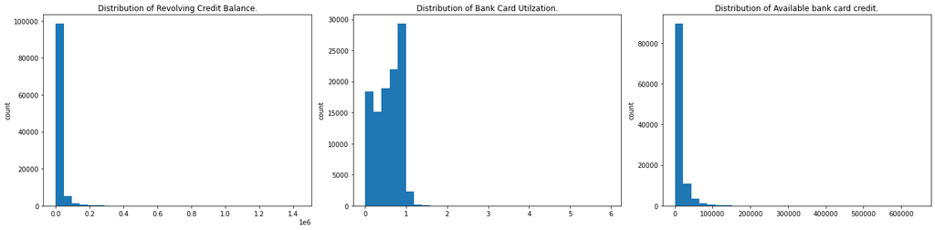

```python
# plotting the credit score range - lower and upper; on subplots

plt.figure(figsize=[20, 5])
plt.subplot(1,3,1)
bins=np.arange(0, loan_df.borrower_apr.max(), 0.025)
plt.hist(data= loan_df_ol, x='revolving_credit_balance', bins=30)
plt.title('Distribution of Revolving Credit Balance.')
plt.ylabel('count')

plt.subplot(1,3,2)
bins=np.arange(0, loan_df_ol.borrower_rate.max(), 0.025)
plt.hist(data= loan_df, x='bank_card_utilization', bins=30)
plt.title('Distribution of Bank Card Utilzation.')
plt.ylabel('count')

plt.subplot(1,3,3)
bins=np.arange(0, loan_df_ol.borrower_rate.max(), 0.025)
plt.hist(data= loan_df, x='available_bank_card_credit', bins=30)
plt.title('Distribution of Available bank card credit.')
plt.ylabel('count')

plt.tight_layout()
```

##### Observations:

1. The variables tend to show a right skew

#### 6. Investigating the loan_original_amount

```python
# checking the data type
loan_df_ol[['loan_original_amount']].info()
```

```
<class 'pandas.core.frame.DataFrame'>
RangeIndex: 113937 entries, 0 to 113936
Data columns (total 1 columns):
 #   Column                Non-Null Count   Dtype
---  ------                --------------   -----
 0   loan_original_amount  113937 non-null  int64
dtypes: int64(1)
memory usage: 890.3 KB
```

```python
# checking the summary statistics
loan_df_ol[['loan_original_amount']].describe()
```

|  | loan_original_amount |
| --- | --- |
| count | 113937.00000 |
| mean | 8337.01385 |
| std | 6245.80058 |
| min | 1000.00000 |
| 25% | 4000.00000 |
| 50% | 6500.00000 |
| 75% | 12000.00000 |
| max | 35000.00000 |

```python
#checking for unique values
print('the Bank Loan original Amount contains:', loan_df_ol['loan_original_amount'].nunique(), 'unique values')
```

```
the Bank Loan original Amount contains: 2468 unique values
```

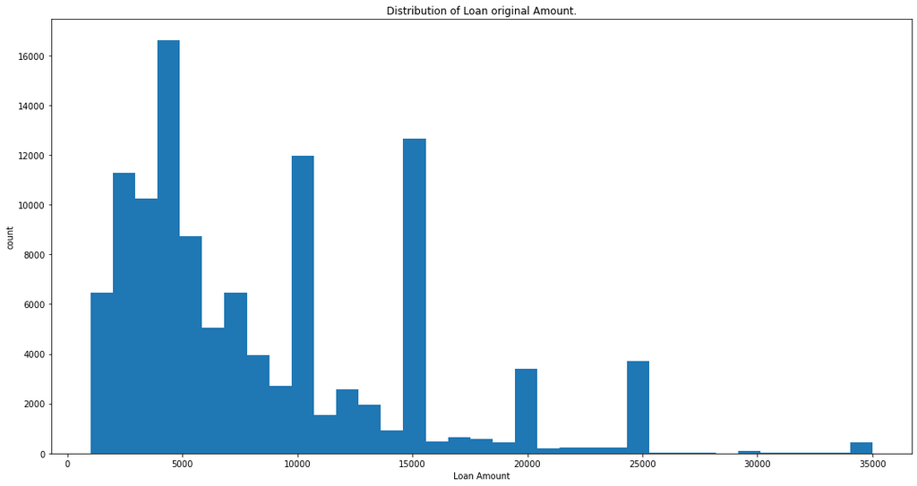

```python
plt.figure(figsize=(15,8))
plt.hist(data= loan_df, x='loan_original_amount', bins=35)
plt.title('Distribution of Loan original Amount.')
plt.ylabel('count')
plt.xlabel('Loan Amount')

plt.tight_layout()
```

### Discuss the distribution(s) of your variable(s) of interest. Were there any unusual points? Did you need to perform any transformations?

1. From the plot chart above we can see that the out if the current observations in the data, 50% are currently under a type of loan, 33% completed the loan, while 17% belond to some state of defaulted, charged off or past due.
2. 3588 (3.15%) of the occupation data was missing
3. As expexcted the borrowers annual exchange rate has more unique values than borrowers rate as it shows an all year round moving average.
4. Both borrowers annual percentage rate and borrowers rate appear to have a normal distribution
5. The difference between the upper and lower is the start values and end values, of which the upper range offsets the lower range by 19
6. there is a appear to be outliers in the data set
7. observations with a lower credit score greater than 600 and an upper credit score less than 820, represent the bulk of our observations.
8. There are 133 outliers in the credit score range. There are observations abnormally low credit scores who were offered loans.  
   Of these lots, approximately 60 have defaulted.

### Of the features you investigated, were there any unusual distributions? Did you perform any operations on the data to tidy, adjust, or change the form of the data? If so, why did you do this?

> Non specific occupation types (other) represents the most occupation type to issued loans.

## Bivariate Exploration

> In this section, investigate relationships between pairs of variables in your data. Make sure the variables that you cover here have been introduced in some fashion in the previous section (univariate exploration).

### 1. What relationship exist between Loan status and Listing Category?

```python
# having a look at the data types of both columns to determine best kind of plot
loan_df_ol[['loan_status', 'listing_category']].info()
```

```
<class 'pandas.core.frame.DataFrame'>
RangeIndex: 113937 entries, 0 to 113936
Data columns (total 2 columns):
 #   Column            Non-Null Count   Dtype
---  ------            --------------   -----
 0   loan_status       113937 non-null  object
 1   listing_category  113937 non-null  object
dtypes: object(2)
memory usage: 1.7+ MB
```

```python
loan_df_ol[['loan_status', 'listing_category']].describe()
```

|  | loan_status | listing_category |
| --- | --- | --- |
| count | 113937 | 113937 |
| unique | 7 | 21 |
| top | Current | Debt Consolidation |
| freq | 56576 | 58308 |

```python
# creating a df that can be used to create a heatmap
df_status_listing= loan_df_ol.groupby(['loan_status', 'listing_category']).size()
df_status_listing= df_status_listing.reset_index(name='count')
df_status_listing= df_status_listing.pivot(columns='loan_status', index='listing_category', values='count')
```

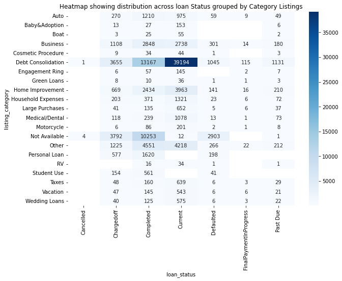

```python
plt.figure(figsize=(10, 7))
sb.heatmap(df_status_listing, cmap='Blues', annot=True, fmt='g')
plt.title('Heatmap showing distribution across loan Status grouped by Category Listings');
```

##### Observation

1. in almost all loan status category, we see that the reason for which our observation access loans the most is for debt consolidation.  
   However, when we look at the defaulted category where we expect to find similar trend of debt consolidation topping the list we find that, observations where there is no record of what the loan is used for tops the chart.
2. Observations for which we have no record of what they were used for, also takes the lead in the loans that have been charged off.

### 2. What trend exists across borrower rate against Loan Status categories?

```python
# having a look at the data types of both columns to determine best kind of plot
loan_df[['loan_status', 'borrower_rate']].info()
```

```
<class 'pandas.core.frame.DataFrame'>
RangeIndex: 113937 entries, 0 to 113936
Data columns (total 2 columns):
 #   Column         Non-Null Count   Dtype
---  ------         --------------   -----
 0   loan_status    113937 non-null  object
 1   borrower_rate  113937 non-null  float64
dtypes: float64(1), object(1)
memory usage: 1.7+ MB
```

```python
loan_df[['loan_status', 'borrower_rate']].describe()
```

|  | borrower_rate |
| --- | --- |
| count | 113937.000000 |
| mean | 0.192764 |
| std | 0.074818 |
| min | 0.000000 |
| 25% | 0.134000 |
| 50% | 0.184000 |
| 75% | 0.250000 |
| max | 0.497500 |

```python
# Check for missing values
loan_df[['loan_status', 'borrower_rate']].isna().sum()
```

```
loan_status      0
borrower_rate    0
dtype: int64
```

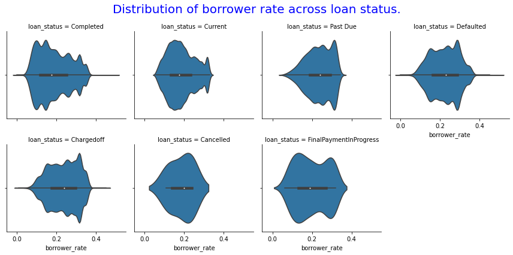

```python
# plot facetgrid
g= sb.FacetGrid(data=loan_df_ol, col='loan_status', col_wrap=4)
g.fig.suptitle('Distribution of borrower rate across loan status.', color='b', fontsize=20)
g.map(sb.violinplot, 'borrower_rate');
```

##### Observation:

1. Observations in the completed loans category, are clustered more around the lower boundary of the borrower rate and have a median borrower rate of less than 0.2.  
   This trend is similar with Current loans category of loans
2. observations in the defaulted, cancelled, past due categories of the loan status features are cluster more towards the upper boundaries of the borrower rate and generally have a median borrower rate of greater than 0.2

```python
# having a look at the data types of both columns to determine best kind of plot
loan_df_ol[['loan_status', 'credit_score_range_upper']].info()
```

```
<class 'pandas.core.frame.DataFrame'>
RangeIndex: 113937 entries, 0 to 113936
Data columns (total 2 columns):
 #   Column                    Non-Null Count   Dtype
---  ------                    --------------   -----
 0   loan_status               113937 non-null  object
 1   credit_score_range_upper  113346 non-null  float64
dtypes: float64(1), object(1)
memory usage: 1.7+ MB
```

```python
loan_df_ol[['loan_status', 'credit_score_range_upper']].describe()
```

|  | credit_score_range_upper |
| --- | --- |
| count | 113346.000000 |
| mean | 704.567731 |
| std | 66.458275 |
| min | 19.000000 |
| 25% | 679.000000 |
| 50% | 699.000000 |
| 75% | 739.000000 |
| max | 899.000000 |

```python
# Check for missing values
loan_df_ol[['loan_status', 'credit_score_range_upper']].isna().sum()
```

```
loan_status                   0
credit_score_range_upper    591
dtype: int64
```

```python
# To check what percentage of data is missing to determine significance
print(f'The percentage of missing data in the credit score upper variable is: {round(loan_df_ol.credit_score_range_upper.isna().sum()/loan_df_ol.credit_score_range_upper.count()*100, 2)}%')
print(('This amount can be considered negligible thus, I will proceed without it'))
```

```
The percentage of missing data in the credit score upper variable is: 0.52%
This amount can be considered negligible thus, I will proceed without it
```

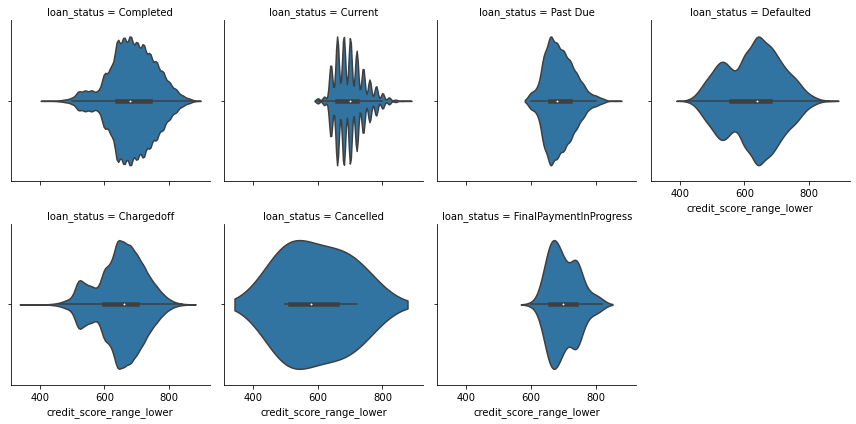

```python
g= sb.FacetGrid(data=loan_df_ol[loan_df_ol['credit_score_range_upper']>350], col='loan_status', col_wrap=4)
g.map(sb.violinplot, 'credit_score_range_lower');
```

### 4. What trend exists between Loan status and Employment status?

```python
# having a look at the data types of both columns to determine best kind of plot
loan_df_ol[['loan_status', 'employment_status']].info()
```

```
<class 'pandas.core.frame.DataFrame'>
RangeIndex: 113937 entries, 0 to 113936
Data columns (total 2 columns):
 #   Column             Non-Null Count   Dtype
---  ------             --------------   -----
 0   loan_status        113937 non-null  object
 1   employment_status  111682 non-null  object
dtypes: object(2)
memory usage: 1.7+ MB
```

```python
loan_df_ol[['loan_status', 'employment_status']].describe()
```

|  | loan_status | employment_status |
| --- | --- | --- |
| count | 113937 | 111682 |
| unique | 7 | 8 |
| top | Current | Employed |
| freq | 56576 | 67322 |

```python
# Check for missing values
loan_df_ol[['loan_status', 'employment_status']].isna().sum()
```

```
loan_status             0
employment_status    2255
dtype: int64
```

```python
print(f'The percentage of missing data in the credit score upper variable is: {round(loan_df_ol.employment_status.isna().sum()/loan_df_ol.employment_status.count()*100, 2)}%')
print(('This amount can be considered negligible thus, I will proceed without it'))
```

[output not shown]

```python
# creating a df that can be used to create a heatmap
df_loan_em= loan_df_ol.groupby(['loan_status', 'employment_status']).size()
df_loan_em= df_loan_em.reset_index(name='count')
df_loan_em= df_loan_em.pivot(columns='loan_status', index='employment_status', values='count')
```

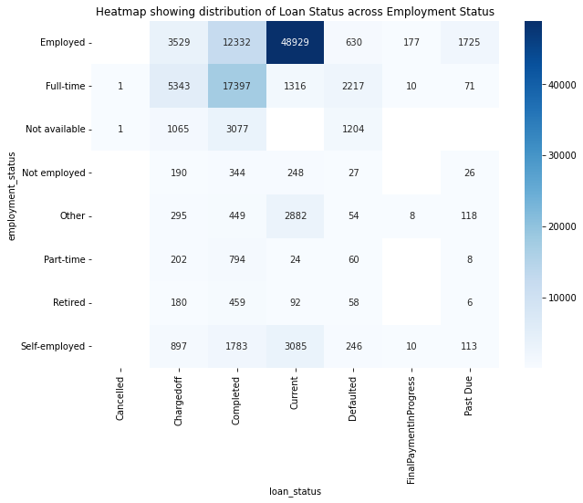

```python
plt.figure(figsize=(10, 7))
sb.heatmap(df_loan_em, cmap='Blues', annot=True, fmt='g')
plt.title('Heatmap showing distribution of Loan Status across Employment Status');
```

##### Observations:

1. Most current loans are accessed by employed.
2. Full time category show the best performance on loan completion but also the worst as the have the highest defaulted and charged off loans.

### 5. What trend exists between Loan status and Income Range?

```python
# having a look at the data types of both columns to determine best kind of plot
loan_df_ol[['loan_status', 'income_range']].info()
```

```
<class 'pandas.core.frame.DataFrame'>
RangeIndex: 113937 entries, 0 to 113936
Data columns (total 2 columns):
 #   Column        Non-Null Count   Dtype
---  ------        --------------   -----
 0   loan_status   113937 non-null  object
 1   income_range  113937 non-null  object
dtypes: object(2)
memory usage: 1.7+ MB
```

```python
loan_df_ol[['loan_status', 'income_range']].describe()
```

|  | loan_status | income_range |
| --- | --- | --- |
| count | 113937 | 113937 |
| unique | 7 | 8 |
| top | Current | $25,000-49,999 |
| freq | 56576 | 32192 |

```python
loan_df_ol[['loan_status', 'income_range']].isna().sum()
```

```
loan_status     0
income_range    0
dtype: int64
```

```python
df_loan_in= loan_df_ol.groupby(['loan_status', 'income_range']).size()
df_loan_in= df_loan_in.reset_index(name='count')
df_loan_in= df_loan_in.pivot(columns='loan_status', index='income_range', values='count')
```

```python
df_loan_in.columns
```

```
Index(['Cancelled', 'Chargedoff', 'Completed', 'Current', 'Defaulted',
       'FinalPaymentInProgress', 'Past Due'],
      dtype='object', name='loan_status')
```

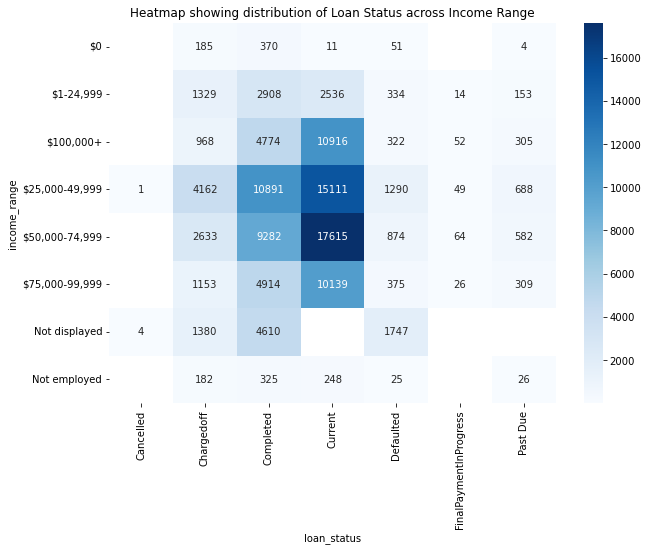

```python
plt.figure(figsize=(10, 7))
sb.heatmap(df_loan_in, cmap='Blues', annot=True, fmt='g')
plt.title('Heatmap showing distribution of Loan Status across Income Range');
```

#### Observations:

1. The not-displayed and 0 category of the income range has an unusually high number of charged off or defaulted.

### 6. What is the Loan original amount distribution across loan status?

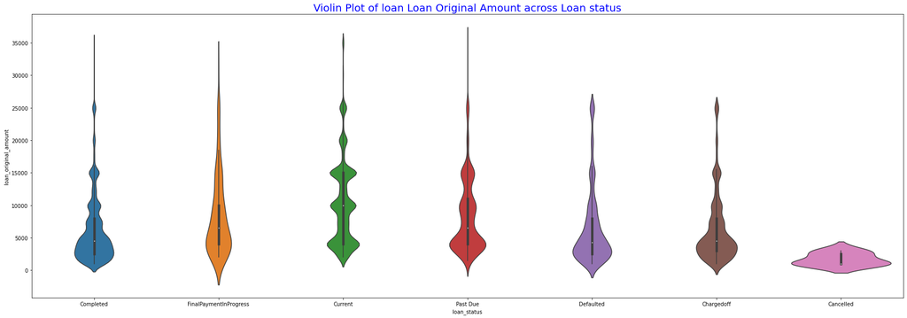

```python
plt.figure(figsize=(30,10))
sb.violinplot(data=loan_df_ol, x='loan_status', y='loan_original_amount', order=loan_status_classes)
plt.title("Violin Plot of loan Loan Original Amount across Loan status", color='b', fontsize=20);
```

#### Observations:

1. Current loans have a higher median amount than any other category

## Multivariate Exploration

### 1. investigating how being a home owner and monthly income affect Loan status

```python
# using a facet grid
plt.figure(figsize=(15, 8))
sb.barplot(data=loan_df_ol, x='loan_status', y='stated_monthly_income', hue='is_borrower_home_owner', ci=False, order=loan_status_classes)
plt.ylabel('Average Monthly Income')
plt.xlabel('Loan Status Category')
plt.title('Monthly Income against Loan Status categorised by Home Ownership', color='b', fontsize=20);
```

[output not shown]

#### Observation:

1. Average monthly income of those who completed their payments do not vary much against those who did not defaulted or had thier loans Charged off.

### 2. How do borrower rates affect loan status for home owners against non home owners?

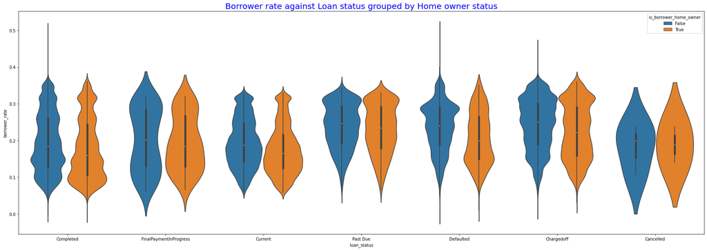

```python
plt.figure(figsize=(30,10))
sb.violinplot(data=loan_df_ol, x='loan_status', y='borrower_rate', hue='is_borrower_home_owner', order=loan_status_classes)
plt.title('Borrower rate against Loan status grouped by Home owner status', color='b', fontsize=20);
```

### 3. Are there differences between home owners and non home owners borrower rate to loan amount across the loan status categories?

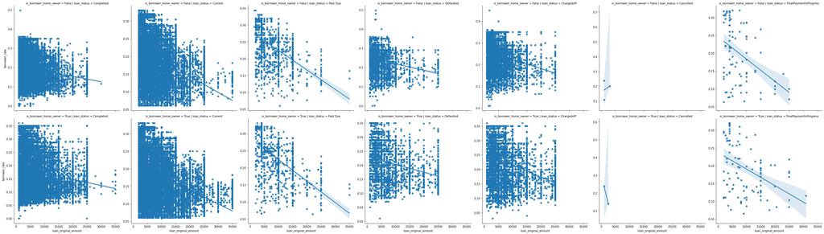

```python
g=sb.FacetGrid(data=loan_df_ol, row='is_borrower_home_owner', col='loan_status', sharey=False, height=6)
g.map(sb.regplot, 'loan_original_amount', 'borrower_rate')
plt.tight_layout();
```

### 4. investigating term and borrower rate on loan status.

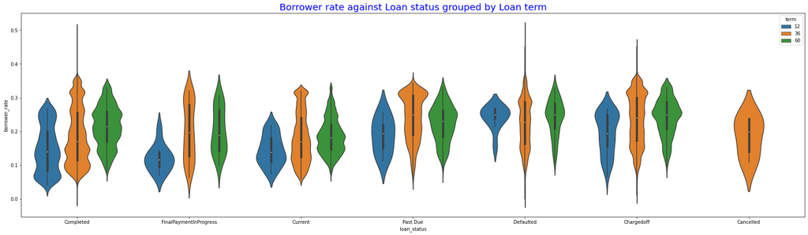

```python
plt.figure(figsize=(30,8))
sb.violinplot(data=loan_df_ol, x='loan_status', y='borrower_rate', hue='term', order=loan_status_classes)
plt.title('Borrower rate against Loan status grouped by Loan term', color='b', fontsize=20)
```

## Conclusions

> At the beginning of this journey, I set out to explore trends that cut across the different categories of the Loan Status. Since there were a whole lot of features with which I could use to find trends, I intuitively picked the following features.

> | 1. Listing Creation Date | 2. Term | 3. Loan Status |
> | --- | --- | --- |
> | 4. Borrower Apr | 5. Borrower Rate | 6. Listing Category |
> | 7. Borrower State | 8. Occupation | 9. Employment Status |
> | 10. Employment Status Duration | 11. Is Borrower Home Owner | 12. Credit Score Range Lower |
> | 13. Credit Score Range Upper | 14. Revolving Credit Balance | 15. Bank Card Utilization |
> | 16. Available Bank Card Credit | 17. Debt To Income Ratio | 18. Income Range |
> | 19. Income Verifiable | 20. Stated Monthly Income | 21. Monthly Loan Payment |
> | 22. Recommendations | 23. Investors | 24. Loan Original Amount |

> From the exploration of these features, I found that the average borrower rate of Loans completed and final payments being processed was generally lower when compared to those that defaulted or charged off.

> Also, I found out that the most common reason for which loans are collect is for debt reconsolidations which forms over 50% of the entire data. the next two: Not disclosed and other are non specific and as such cannot be determined, thus I will say the next specific reasons for which loans are taken are listed below:

> | S/No | Reason for Loan | % of Observation |
> | --- | --- | --- |
> | 1. | Debt Reconsolidation | 51.18 |
> | 2. | Not Available | 14.89 |
> | 3. | Other | 9.21 |
> | 4. | Home Improvement | 6.52 |
> | 5. | Business | 6.31 |

> in almost all loan status category, I found that the reason for which our observation access loans the most is for debt consolidation. However, when we look at the defaulted category where we expect to find similar trend of debt consolidation topping the list we find that, observations where there is no record of what the loan is used for tops the chart.